# MED264: Statistics for Biomedical Informaticss

### Bias introduced if ratings were analyzed as a correlation

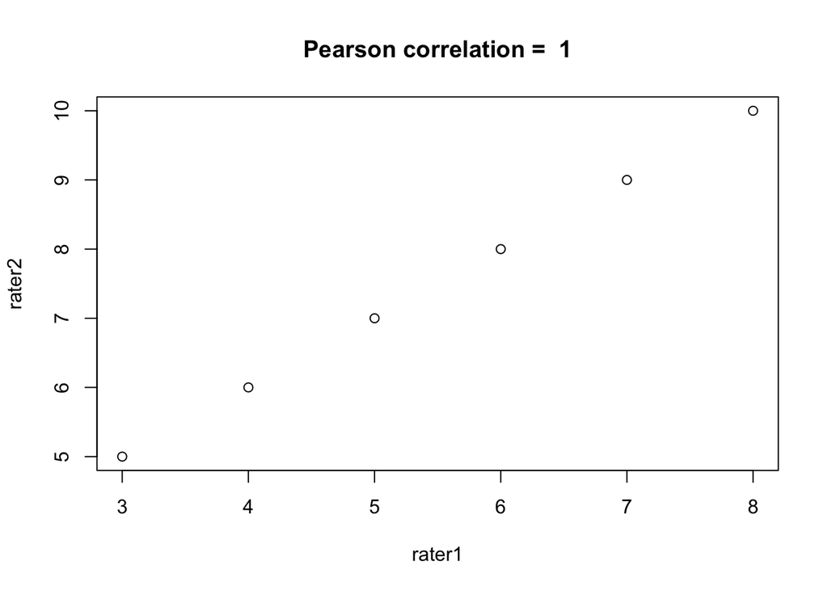

```r
rater1 = c(3, 4, 5, 6, 7, 8)
rater2 = c(5, 6, 7, 8, 9, 10)

raters.m = cbind(rater1, rater2)

plot(rater1, rater2,
     main = paste("Pearson correlation = ", cor(rater1, rater2)) )
```

Reference: https://www.ncbi.nlm.nih.gov/pubmed/25852260

### Data object for interrater agreement

```r
library(irr)
data(diagnoses)
head(diagnoses)
```

```
##                    rater1                  rater2                  rater3
## 1             4. Neurosis             4. Neurosis             4. Neurosis
## 2 2. Personality Disorder 2. Personality Disorder 2. Personality Disorder
## 3 2. Personality Disorder        3. Schizophrenia        3. Schizophrenia
## 4                5. Other                5. Other                5. Other
## 5 2. Personality Disorder 2. Personality Disorder 2. Personality Disorder
## 6           1. Depression           1. Depression        3. Schizophrenia
##             rater4           rater5           rater6
## 1      4. Neurosis      4. Neurosis      4. Neurosis
## 2         5. Other         5. Other         5. Other
## 3 3. Schizophrenia 3. Schizophrenia         5. Other
## 4         5. Other         5. Other         5. Other
## 5      4. Neurosis      4. Neurosis      4. Neurosis
## 6 3. Schizophrenia 3. Schizophrenia 3. Schizophrenia
```

### Cohen’s Kappa for interrater agreement

```r
library(irr)
data(diagnoses)
kappa2( diagnoses[,1:2] )
```

```
##  Cohen's Kappa for 2 Raters (Weights: unweighted)
##
##  Subjects = 30
##    Raters = 2
##     Kappa = 0.651
##
##         z = 7
##   p-value = 2.63e-12
```

### Difference between logistic vs. linear regression

1. Outcome variable is binary (or dichotomous), not continous.
2. The nature of the relationship between the outcome and independent variables:
- linear regression:

  $$E[Y|x] = \beta_0 + \beta_1 x$$
- logistic regression:

  $$logit( E[Y|x] ) = \beta_0 + \beta_1 x$$

  where
  $$logit(t) = log( \frac{t}{1 - t} )$$
- the conditional mean of the regression equation is formulated to be bounded between 0 and 1.
3. The conditional distribution of the outcome variable: binomial, not the normal.

### Example: treatment for drug abuse

Goal was to compare treatment programs of different durations in the reduction of drug abuse and in the prevention of high-risk HIV behavior.

- DFREE: returned to drug use prior the study end date
- AGE: age at enrollment
- IVHX: IV drug use history at admission
- NRUGTX: number of prior drug treatment
- RACE: subject race (0 for white, and otherwise 1)
- TREAT: treatment site (0 for A and 1 for B)

Reference: Hosmer DW and Lemeshow S, Applied Logistic Regression, Johsn Wiley and Sons, Inc.

### Estimated coefficients in a treatment study for drug abuse

```r
library(pROC)
library(ResourceSelection)

rawdata = read.table("http://course1.winona.edu/bdeppa/Biostatistics/Data%20Sets/umaru.txt",
                 header = T)
uis = rawdata
uis$IVHX = factor(rawdata$IVHX)
uis$RACE = factor(rawdata$RACE)
uis$TREAT = factor(rawdata$TREAT)
uis$SITE = factor(rawdata$SITE)

m1 = glm(DFREE ~ AGE + NDRUGTX + IVHX  + RACE+ TREAT, data = uis, family="binomial")
round(summary(m1)$coef, 3)
```

```
##             Estimate Std. Error z value Pr(>|z|)
## (Intercept)   -2.356      0.550  -4.282    0.000
## AGE            0.051      0.017   2.944    0.003
## NDRUGTX       -0.063      0.026  -2.464    0.014
## IVHX2         -0.593      0.286  -2.070    0.038
## IVHX3         -0.760      0.249  -3.052    0.002
## RACE1          0.208      0.221   0.940    0.347
## TREAT1         0.439      0.199   2.204    0.028
```

```r
### esimated coefficients and p-values
kable( round(summary(m1)$coef, 3) )
```

|  | Estimate | Std. Error | z value | Pr(>\|z\|) |
| --- | --- | --- | --- | --- |
| (Intercept) | -2.356 | 0.550 | -4.282 | 0.000 |
| AGE | 0.051 | 0.017 | 2.944 | 0.003 |
| NDRUGTX | -0.063 | 0.026 | -2.464 | 0.014 |
| IVHX2 | -0.593 | 0.286 | -2.070 | 0.038 |
| IVHX3 | -0.760 | 0.249 | -3.052 | 0.002 |
| RACE1 | 0.208 | 0.221 | 0.940 | 0.347 |
| TREAT1 | 0.439 | 0.199 | 2.204 | 0.028 |

### ROC Curve

```r
### load R packages
library(pROC)
library(ResourceSelection)

### load data from URL
rawdata = read.table("http://course1.winona.edu/bdeppa/Biostatistics/Data%20Sets/umaru.txt",
                 header = T)

### convert to factor variable
uis = rawdata
uis$IVHX = factor(rawdata$IVHX)
uis$RACE = factor(rawdata$RACE)
uis$TREAT = factor(rawdata$TREAT)
uis$SITE = factor(rawdata$SITE)


### fit a logistic regression model
m1 = glm(DFREE ~ AGE + NDRUGTX + IVHX + RACE + TREAT, data = uis, family="binomial")

### Goodness of Fit test
hoslem.test(m1$y, m1$fitted)
```

```
##
##  Hosmer and Lemeshow goodness of fit (GOF) test
##
## data:  m1$y, m1$fitted
## X-squared = 5.5491, df = 8, p-value = 0.6976
```

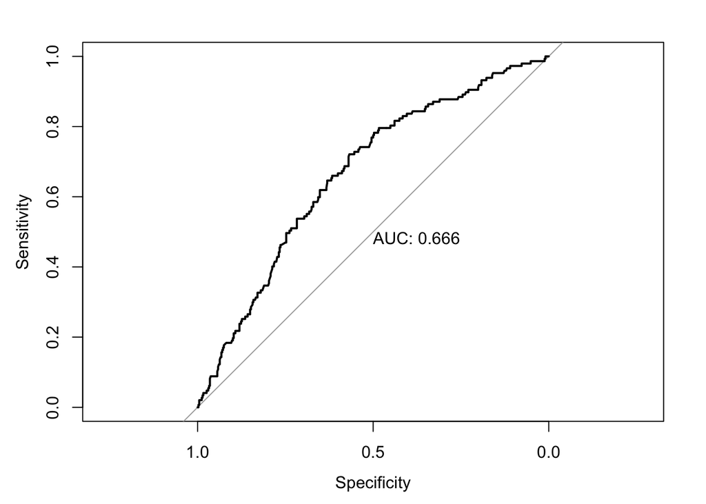

```r
### ROC curve and AUC
myroc = roc(m1$y, m1$fitted)
plot(myroc, print.auc=TRUE)
```

### Survival Anslysis

- The most important difference between the outcome variables modeled via linear/logistic regression and survival analysis is the fact that we may observe the survival time partially
- For those subjects who died, it is the outcome variable of interest, the actual survival time.
- However, for subjects who were alive at the end of the study, or for subjects who were lost, the time variable indicates the length of follow-up, which is a partial or incomplete observation of survival time

These incomplete observations are referred to as being censored

- If we ignore the consoling and treat the censored observations as if they were measurements of survival time, then the resulting sample statistics are NOT estimators of the respective parameters of the survival time distribution.
- Reference: Hosmer,DW et al. (1999) Applied Survival Analysis, Danvers,MA. John Wiley and Sons, Inc.

### Data object for survival analysis

```r
library(survival)
fname = "https://stats.idre.ucla.edu/stat/r/examples/asa/hmohiv.csv"
hmohiv = read.table(fname,sep=",", header = TRUE)
head(hmohiv)
```

```
##   ID time age drug censor    entdate     enddate
## 1  1    5  46    0      1 5/15/1990  10/14/1990
## 2  2    6  35    1      0 9/19/1989   3/20/1990
## 3  3    8  30    1      1 4/21/1991  12/20/1991
## 4  4    3  30    1      1  1/3/1991    4/4/1991
## 5  5   22  36    0      1 9/18/1989   7/19/1991
## 6  6    1  32    1      0 3/18/1991   4/17/1991
```

### Survival curves

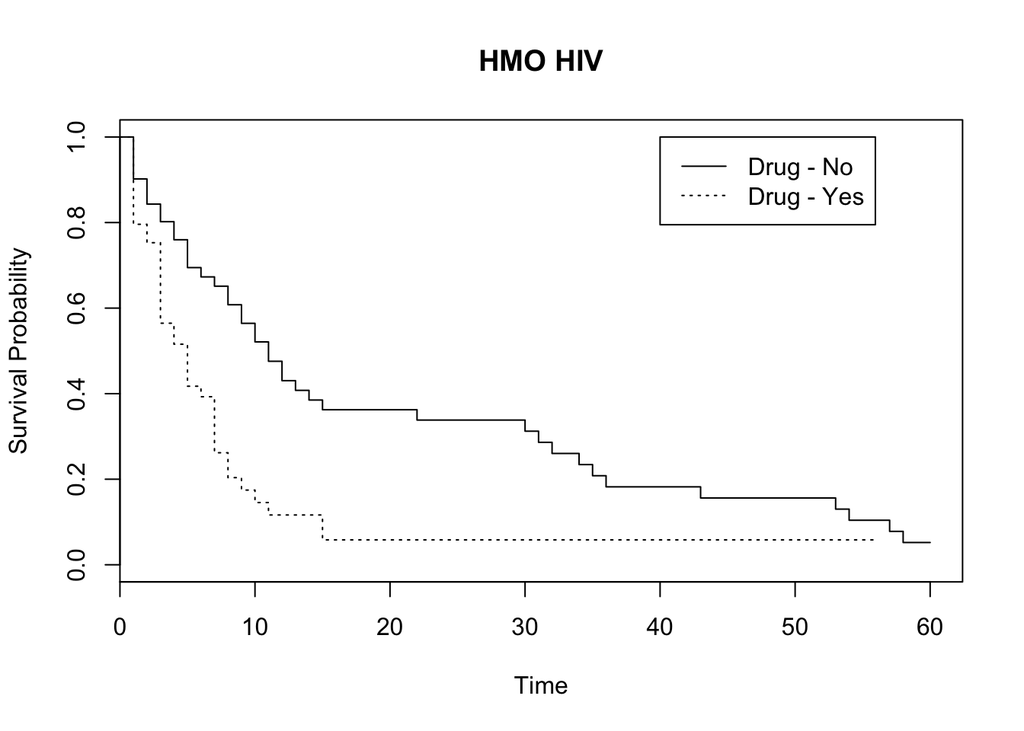

```r
library(survival)
fname = "https://stats.idre.ucla.edu/stat/r/examples/asa/hmohiv.csv"
hmohiv = read.table(fname,sep=",", header = TRUE)
timestrata.surv <- survfit( Surv(time, censor) ~ strata(drug),
                            hmohiv,
                            conf.type="log-log")
plot(timestrata.surv, lty=c(1,3),
     main = "HMO HIV",
     xlab="Time", ylab="Survival Probability")
legend(40, 1.0, c("Drug - No", "Drug - Yes") , lty=c(1,3) )
```

### Test for a difference between two survival curves

```r
library(survival)
fname = "https://stats.idre.ucla.edu/stat/r/examples/asa/hmohiv.csv"
hmohiv = read.table(fname,sep=",", header = TRUE)
survdiff(Surv(time, censor) ~ drug, data=hmohiv, rho=0)
```

```
## Call:
## survdiff(formula = Surv(time, censor) ~ drug, data = hmohiv,
##     rho = 0)
##
##         N Observed Expected (O-E)^2/E (O-E)^2/V
## drug=0 51       42     54.9      3.02      11.9
## drug=1 49       38     25.1      6.60      11.9
##
##  Chisq= 11.9  on 1 degrees of freedom, p= 0.000575
```